# Bank Customer Churn Prediction Model

Victor Lucas Santana

[figure not shown]

# 1 Introduction

The main goal of this work is to develop a machine learning model to predict bank customer churn, also known as customer attrition, witch is the phenomenon where customers stop doing business with a bank or switch to another bank. The dataset that will be analised contains several custumers bank features, this features will be the input of the machine learning model to predict the likelihood of customer churn.

# 2 Exploratory Data Analysis

## 2.1 Loading the dataset and the libraries that will be used

```python
#  Import libraries
import pandas as pd
import matplotlib.pyplot as plt
import seaborn as sns
import numpy as np
from sklearn import preprocessing
from sklearn.model_selection import train_test_split
from sklearn.linear_model import LogisticRegression
from sklearn.neighbors import KNeighborsClassifier
from sklearn.ensemble import RandomForestClassifier
from sklearn.model_selection import GridSearchCV
from sklearn.metrics import confusion_matrix

# Load the dataset
df = pd.read_csv('dataset.csv')
```

## 2.2 Visualizing the Data

```python
df.info()
```

```
## <class 'pandas.core.frame.DataFrame'>
## RangeIndex: 10000 entries, 0 to 9999
## Data columns (total 12 columns):
##  #   Column            Non-Null Count  Dtype
## ---  ------            --------------  -----
##  0   customer_id       10000 non-null  int64
##  1   credit_score      10000 non-null  int64
##  2   country           10000 non-null  object
##  3   gender            10000 non-null  object
##  4   age               10000 non-null  int64
##  5   tenure            10000 non-null  int64
##  6   balance           10000 non-null  float64
##  7   products_number   10000 non-null  int64
##  8   credit_card       10000 non-null  int64
##  9   active_member     10000 non-null  int64
##  10  estimated_salary  10000 non-null  float64
##  11  churn             10000 non-null  int64
## dtypes: float64(2), int64(8), object(2)
## memory usage: 937.6+ KB
```

Since there are no missing values to deal with, the data is ready to the analysis.

## 2.3 Descriptions of the features that will be analyzed

• customerID: A unique identifier for each customer.

• credit score: The credit score of the customer, which indicates their creditworthiness.

• country: The country where the customer is located.

• gender: The gender of the customer.

• age: The age of the customer.

• tenure: The number of years the customer has been with the bank.

• balance: The bank account balance of the customer.

• products number: The number of bank products the customer has subscribed to.

• credit_card: Indicates whether the customer has an active credit card (1) or not (0).

• active_member: Indicates whether the customer is an active member of the bank (1) or not (0).

• estimated_salary: The estimated salary of the customer.

• churn: Indicates whether the customer has churned (1) or not (0).

## 2.4 Plots and tables that helps to get some insights on the correlation between the features

```python
# Categorical variables Gender x Country
pd.crosstab(df['gender'], df['country'])
```

```
## country  France  Germany  Spain
## gender
## Female     2261     1193   1089
## Male       2753     1316   1388
```

This table above shows the customer’s gender by each country in this dataset.

```python
# Table with numerical variables containing maximum value,
# minimum value and mean
num_var = ['credit_score', 'age', 'tenure','balance',
           'products_number', 'estimated_salary']
num_var_cols = ['Variables', 'Min Value', 'Mean Value',
                'Max Value']
num_var_rows = []
for var in num_var:
          num_var_rows.append([var, min(df[var]),
          round(df[var].mean(),2), max(df[var])])

num_var_df  = pd.DataFrame(num_var_rows, columns = num_var_cols)
print(num_var_df.to_string(index=False))
```

```
##        Variables  Min Value  Mean Value  Max Value
##     credit_score     350.00      650.53     850.00
##              age      18.00       38.92      92.00
##           tenure       0.00        5.01      10.00
##          balance       0.00    76485.89  250898.09
##  products_number       1.00        1.53       4.00
## estimated_salary      11.58   100090.24  199992.48
```

The table above shows the minimum the mean and the maximum values from each numerical variables.

```python
# Categorical variables yes or no
bin_cat_var = ('Active Credit Card', 'Active Member', 'Churn')
count_value = {
    'Yes': (
         (df['credit_card'] == 1).sum(),
         (df['active_member'] == 1).sum(),
         (df['churn'] == 1).sum()
),
    'No': (
        (df['credit_card'] == 0).sum(),
        (df['active_member'] == 0).sum(),
        (df['churn'] == 0).sum()
)
}

x = np.arange(len(bin_cat_var))
width = 0.25
multiplier = 0

fig, ax = plt.subplots(layout='constrained')

for attribute, measurement in count_value.items():
    offset = width * multiplier
    rects = ax.bar(x + offset, measurement, width, label=attribute)
    ax.bar_label(rects, padding=3)
    multiplier += 1

ax.set_title('Features Customers Has')
ax.set_xticks(x + width, bin_cat_var)
ax.legend(loc='upper left', ncols=2)
ax.set_ylim(0, 9000)
```

```
## (0.0, 9000.0)
```

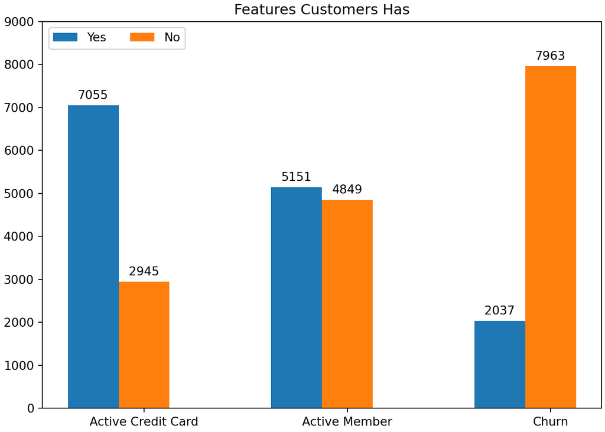

```python
plt.show()
```

This above plot shows how many customers of the bank have (Yes) and have not (No) an active credit card, also shows how many customers are active in the bank and the number of customers that have or have not churned. By looking at the plot is clear that in this dataset, most clients (79.63%) have not churned and also have active credit card and are active members of the bank.

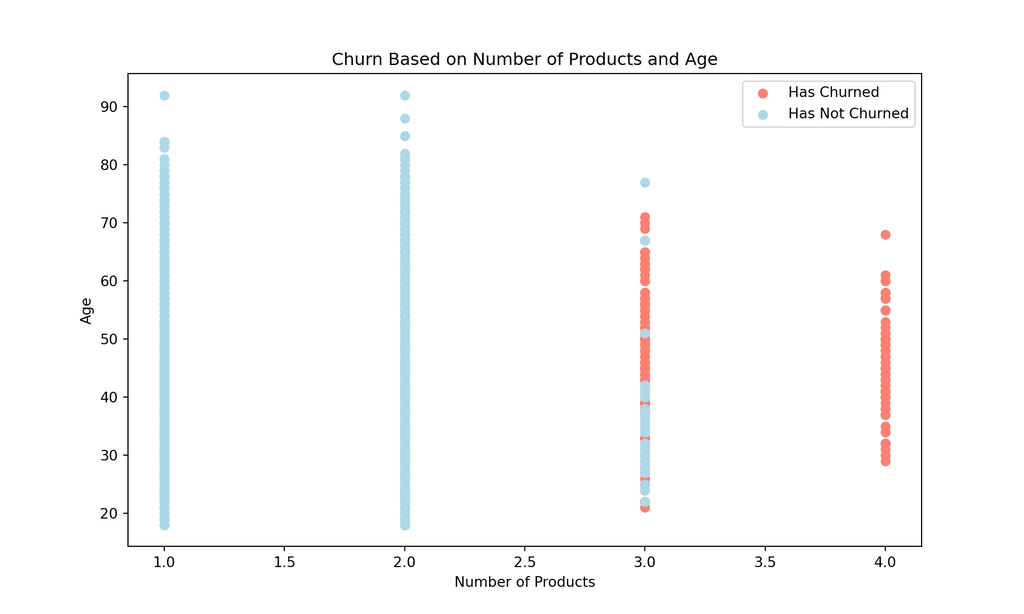

```python
# Churn by Estimated Salary and Credit Score
plt.figure(figsize=(10,6))

# plt Yes
plt.scatter(df['products_number'][df['churn'] == 1],
 df['age'][df['churn']== 1],
 c = 'salmon')
# plt No
plt.scatter(df['products_number'][df['churn'] == 0],
 df['age'][df['churn']== 0],
 c = 'LightBlue')


plt.title('Churn Based on Number of Products and Age')
plt.xlabel('Number of Products')
plt.ylabel('Age')
plt.legend(['Has Churned', 'Has Not Churned'])
```

The plot obove tells that the customers that have two or less products tend not to churn regardless of the age. On the other hand, the clients the have three or more products and are over forty years old are more likely to churn.

# 3 Machine Learning

## 3.1 Managing the variables to use in the machine learning

The customer ID variable does not serve the purpose of this analysis, so it is going to be removed from the dataset.

```python
del df['customer_id']
```

Using label encoder to transform categorical variables into numerical variables so they can fit the model.

```python
# Dealing with categorical variables
label_encoder = preprocessing.LabelEncoder()
df['country'] = label_encoder.fit_transform(df['country'])
df['gender'] = label_encoder.fit_transform(df['gender'])
```

## 3.2 Split the features from the target

The features will be the input for the model to make predictions on. And the target is the output that the model will be predicting.

```python
# Picking up the features
features = list(df.columns)
features.remove('churn')
# Split features and target.
X = df[features]
y = df['churn']
```

## 3.3 Split the the data

Separate the the data in two parts. One for training the model and other to test the accuracy of the predictions. This is important to validate and check if the model is in deed learning and being able to predict results from new inputs. In this case, 67% of all the data will be set apart for training and 33% is going to be use to test the model.

```python
X_train, X_test, y_train, y_test = train_test_split(X, y,
                                                    random_state=0,
                                                    test_size=0.33
)
```

## 3.4 Picking up the best machine learning model to use

Fitting the machine learning model with the training data to evaluate which one has the best performance and the highest scores.

```python
models = [
  KNeighborsClassifier(),
  LogisticRegression(random_state = 0),
  RandomForestClassifier(random_state = 0)
]
# Loop for to fit and score each model
model_score = []
for model in models:
 model.fit(X_train, y_train)
 model_score.append(model.score(X_test, y_test))
# Print scores
print('KNeighborsClassifier score is' , model_score[0])
print('LogisticRegression score is' , model_score[1])
print('RandomForestClassifier score is', model_score[2])
```

```
## KNeighborsClassifier score is 0.7551515151515151
```

```
## LogisticRegression score is 0.7815151515151515
```

```
## RandomForestClassifier score is 0.8618181818181818
```

## 3.5 Optimizing parameter values for the algorithms using GridSearchCV

Since Random Forest Classifier is the model with the highest score, we will proceed to find the optimal hyperparameters to increase the model performance.

```python
# RandomForestClassifier
rand_forst = {
     'n_estimators': [79, 84, 89],
     'max_depth': [7, 10, 13],
     'max_leaf_nodes':[49, 54, 59]
}

gs_rand_forst = GridSearchCV(RandomForestClassifier(random_state = 0),
                             param_grid=rand_forst,
                             cv = 5,
                             verbose = True)

gs_rand_forst.fit(X_train, y_train)

print('RandomForestClassifier optimized params are',
       gs_rand_forst.best_params_)
print('RandomForestClassifier new score is',
       gs_rand_forst.score(X_test, y_test))
```

```
## RandomForestClassifier optimized params are {max_depth: 10,
##  max_leaf_nodes: 59, n_estimators: 84}
```

```
## RandomForestClassifier new score is 0.8648484848484849
```

# 4 Conclusion

RandomForestClassifier had the highest score. So for the conclusion of this work the model is going to be tested to evaluate the accuracy of the predictions.The confusion matrix shows all false positives from each label and the correct predictions in the main diagonal. The labels are 0 for the customer that has not churned and 1 for the customer that has churned.

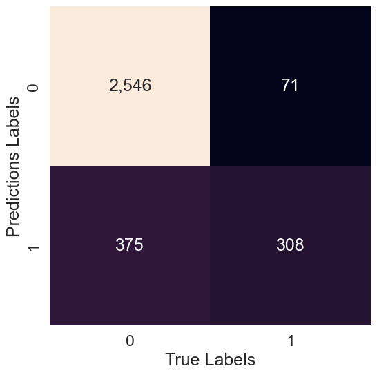

```python
predictions = gs_rand_forst.predict(X_test)
sns.set(font_scale=1.5)
fig, ax = plt.subplots(figsize=(6,6))
ax = sns.heatmap(confusion_matrix(y_test,predictions),
 annot=True,
 cbar=False,
 fmt=',.0f')
plt.xlabel('True Labels')
plt.ylabel('Predictions Labels');
```

This result was already expected, since the dataset contains a lot more customer that has not churned.

```python
df['churn'].value_counts()
```

```
## churn
## 0    7963
## 1    2037
## Name: count, dtype: int64
```